# Aprendizaje Automático

## Integrantes:

- Daniel Roman Ramirez
- Obed Ríos-Ruiz

# Ingeniería de descriptores

# Contexto de los datos

La información con la que se cuenta es una base de ventas de una compañía cementera que distribuye distintos tipos de productos a granel y sacos a lo largo de un país en Suramerica. Dicha información contiene todo el nivel de detalle de facturación y otras características logísticas y de entrega de las ordenes, incluyendo datos sobre los clientes

## 1. Recopilación de datos

A continuación se despliega una arquitectura teórica para la recopilación de los datos de la compañía basada en *Microsoft Azure*

### 1.1. Arquitectura

En este esquema existe una fuente de datos que es poblada por transacciones en línea ejecutadas en un sistema `ERP SAP` hacia tablas que son consumidas por transformadores que las llevan hacia un objeto query en `BW`.

[figure not shown]

Desde allí el query es consultado mediante un query **MDX** a través de una actividad `copy data` en una instancia de `Azure DataFactory` para cada período mensual vencido y desplazado hacia un `Azure DataLake` en formato `.csv` con una configuración de extracción predeterminada (separadores, encoding y esquema).

[figure not shown]

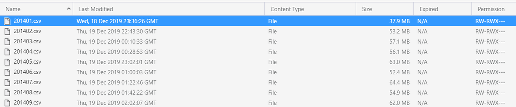

El esquema actual tiene las siguientes características

| Positivas | Negativas |
| --- | --- |
| Parametrizable a mayor frecuencia de consulta | Invasivo para el sistema ERP |
| Alto nivel de conectividad con otros servicios | Restrictivo a servicios de Microsoft |
| Escalable a grandes movimientos de datos | Pay-as-you-go o subscripción |
| Monitoreable en sus flujos | Vulnerabilidad de la información desplazada |
| Procesamiento y transformación en línea | Complejidad de las herramientas |
| Paralelizable | Estres a bodega legacy |

### 1.2. Resumen datos

Bajo una muestra de datos de un mes (2019-01) se genera el siguiente resumen de la entidad de información

| Descripción general | Nombre base | Formato | Cantidad de columnas | Cantidad de filas | Cantidad de variables categorías | Cantidad de variables numéricas | Cantidad de variables temporales |
| --- | --- | --- | --- | --- | --- | --- | --- |
| Información de ventas de clientes | 201901 | csv | 82 | 114.590 | 68 | 10 | 4 |

Las condiciones de éstos datos no se modificarán en el formato ni tampoco su esquema (presentado a continuación), por lo que se estima un volumen de datos para un año de $1.500.000$ registros.

### 1.3. Metadata

La siguiente tabla despliega el cuerpo técnico de la fuente de información, donde se expone la **variable** (nombre de negocio), su **tipo**, **id** (nombre técnico), **accepta NA's** y **ejemplo**.

| Variable | Tipo | Id | Acepta NA's | Ejemplo |
| --- | --- | --- | --- | --- |
| Clase de Factura | StringType | Clase_de_Factura | True | Anticipado / Devolución |
| Sociedad | StringType | Sociedad | True | Compañia S.A |
| Segmento | StringType | Segmento | True | Detallista |
| Tipo de negocio | StringType | Tipo_de_negocio | True | Industrial/Masivo |
| Cliente | StringType | Cliente | True | Pepito Perez |
| Tipologia de obra | String_type | Tipolog_a_de_obra | True | Residencial |
| Grupo de precios | StringType | Grupo_de_precios | True | Contratista |
| Tipo descargue | StringType | Tipo_descargue | True | Descargue mecanizado |
| Clase de orden | StringType | Clase_de_orden | True | Sin asignar |
| Material | StringType | Material | True | CMTO GRIS |
| Grupo de productos | StringType | Grupo_de_productos | True | CEMENTO BLANCO |
| Tipo de material | StringType | Tipo_de_material | True | ESTRUCTURAL |
| Tipo de empaque | StringType | Tipo_de_empaque | True | 40 Kg |
| Presentacion | StringType | Presentaci_n | True | SACOS |
| Pagador papá | StringType | Pagador___Pap_ | True | Pepito Perez |
| Planta logistica | StringType | Planta_log_stica | True | CD PT BOGOTA |
| Subsegmento | StringType | Subsegmento | True | Edificaciones |
| Departamento | StringType | Departamento | True | Cundinamarca |
| Organizacion ventas | StringType | Organizaci_n_ventas | True | Regional Cementos |
| Entrega/Retira | StringType | Entrega_Retira | True | Enviado |
| Dirección de entrega | StringType | Direcci_n_de_entrega | True | Pepito Perez Cia |
| Cabecera municipal SD | StringType | Cabecera_municipal_SD | True | CUN_SOACHA |
| Hijo facturable Obra | StringType | Hijo_facturable___Obra | True | Pepito Perez SA |
| Nombre Obra | StringType | Nombre_Obra | True | Construcción Pepito |
| Descripcion segundas marcas | StringType | Descripci_n_segundas_marcas | True | Cemento |
| Asesor Comercial | StringType | Asesor_Comercial | True | KKO02/Sin asignar |
| Subsegmento destinatario mc | StringType | Subsegmento__destinatario_mc_a__ | True | DETALLISTA |
| Departamento DANE | StringType | Departamento_DANE | True | CUNDINAMARCA |
| Departamento Destinatario mc | StringType | Departamento__Destinatario_mc_a__ | True | CUNDINAMARCA |
| Departamento SD | StringType | Departamento_SD | True | CUNDINAMARCA |
| Regional destinatario mc a | StringType | Regional__destinatario_mc_a__ | True | CENTRO |
| Regional DANE | StringType | Regional_DANE | True | CENTRO |
| Segmento Pagador | StringType | Segmento__Pagador_ | True | DETALLISTA |
| Tipo de negocio Pagador | StringType | Tipo_de_negocio__Pagador_ | True | Masivo |
| Planta productora | StringType | Planta_productora | True | Planta Name |
| Descriptores clave | ObjectType | Descriptores_clave | True | Clase_de_Factura_Clave |
| Ingresos presupuesto maestro | DoubleType | Ingresos_Presupuesto_Maestro | True | 100555 |
| Ingresos Real | DoubleType | Ingresos_Real | True | 233888 |
| Volumen presupuesto Maestro | DoubleType | Volumen_Presupuesto_Maestro | True | 0 |
| Volumen Real TN | DoubleType | Volumen_Real__TN_ | True | 9.7 |
| Volumen proyectado TN | DoubleType | Volumen_Proyectado__TN_ | True | 0 |
| Precio Presupuesto Maestro | DoubleType | Precios_Presupuesto_Maestro | True | 0 |
| Volumen Real M3 | DoubleType | Volumen_Real__M3_ | True | 0 |
| Volumen Real Total TN M3 | DoubleType | Volumen_Proyectado__M3_ | True | 0 |
| Volumen Real Total TN M3 | DoubleType | Volumen_Real_Total__TN___M3_ | True | 0 |
| Volumen Proyectado total TN M3 | DoubleType | Volumen_Proyectado_Total___TN___M3_ | True | 0 |
| Dia Natural | StringType | D_a_natural | True | 2019-01-01 |
| Año Natural | StringType | A_o_natural_Mes | True | 2019-01 |

Adicionalmente se cuenta con el siguiente mapa conceptual, donde se segmenta la información por nivel de jerarquía, permitiendo identificar características de mayor relevancia o algunas que resúmen la dimensión por completo.

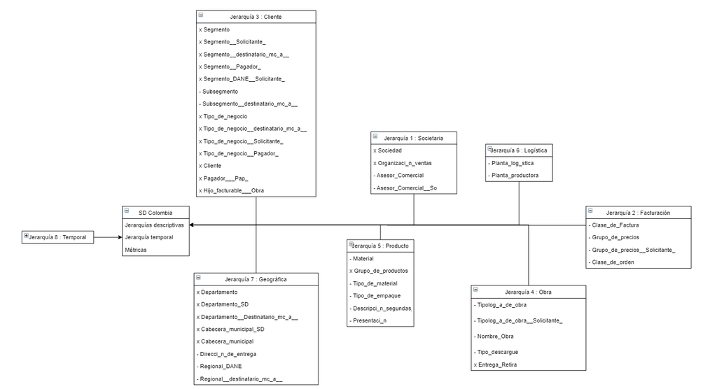

## 2. Detección de características

### 2.1. Caso de negocio

A la compañía de cementos le interesaría encontrar predicciones certeras de sus ventas en diferentes ventanas temporales, buscando asegurar niveles de confiabilidad de, al menos, $90\%$ en $1$ mes, $80\%$ a $3$ meses y $70\%$ a $6$ meses o más. Dichas predicciones deben aplicarse a todos los niveles de jerarquía que se tienen en la estructura comercial.

En la medida de lo posible se desearía anexar información macro-economica y conocimiento de mercado adicional que permita robustecer las proyecciones; no obstante, esta condición no es necesaria.

### 2.2. Interpretación caso de negocio

El problema se traduce en encontrar un modelo que consuma la información histórica (input) de las ventas de la compañía y genere estimaciones con altos niveles de certeza para la variable de volumen.

### 2.3. Detección

#### 2.3.1. Redundancia de variables

En la fuente de información, y basándose en el diagrama de jerarquías previamente expuesto, se identifica la oportunidad de remover todos los *descriptores clave*, entendidos como la representación en clave de los valores en texto o valor, así, por ejemplo, el campo `"Subsegmento"` (Edificaciones) tendría un campo gemelo `"Subsegmento Clave"` (102) el cual se retira por ser redudante. Por ello se procede a la creación de un diccionario que permita resumir claves y características y posteriormente del dataset seleccionar los campos clave relevantes.

En cuanto a las variables numéricas se conserva exclusivamente la variable `"Volumen Real Total (TN - M3)"`.

## 3. Extracción de características

### 3.1. Variables a considerar

Para efectos de depuración se cuenta con información de negocio suministrada por un experto, donde se entrega una lista de características conocida que facilitara el proceso de ingeniería de descriptores dadas sus características de poca redundancia y alta informatividad. Más específicamente se comparten los campos descriptivos, temporales y métricas de interés que más peso tienen en la generación de las estimaciones.

| Tipo | Variable |
| --- | --- |
| Descriptora | Tipo de negocio |
| Descriptora | Grupo de productos |
| Descriptora | Segmento |
| Descriptora | Subsegmento destinatario mcía |
| Descriptora | Departamento Destinatario mcía |
| Descriptora | Sociedad |
| Descriptora | Pagador papá |
| Descriptora | Regional destinatario (mcía) |
| Temporal | Día natural |
| Numérica | Volumen Real Total (TN - M3) |

; no obstante, se agregarán un par de variables adicionales para ejecutar el método

### 3.2. Filtros a implementar

Adicionalmente el negocio indica un grupo de información en el cual le gustaría hacer enfásis, más específicamente grupos particulares de productos para sus dos líneas de negocio, dadas las dinámicas de negocio

| Variable | Filtros |
| --- | --- |
| Grupo de productos | Cementos gris, concretos |
| Líneas de negocio | Empacado, granel |

### 3.3. Ejecución de extracción

```python
from IPython.display import display, HTML
```

```python
%matplotlib inline
```

```python
import os
import glob

from pathlib import Path
```

```python
import pandas as pd
import datetime as dt
import numpy as np
import matplotlib.pyplot as plt

from sklearn import preprocessing
from sklearn.ensemble import RandomForestRegressor
from sklearn import metrics
from sklearn.model_selection import train_test_split

from mlxtend.feature_selection import SequentialFeatureSelector as sfs

pd.options.display.max_columns = None
```

```python
dir_str = r'C:\Users\orios\OneDrive - Cementos Argos S.A\Documentos\Projekte'
base_path = Path(dir_str)
projekt = '0. Bitacora\Master\CM0891\CM0891'

base_rute = os.path.join(base_path, projekt)
```

```python
data_source = 'ds2_SALES'

list_f = glob.glob(os.path.join(base_path, projekt, 'data_sources', data_source, 'data', '*.csv'))
```

```python
base_data = pd.concat([pd.read_csv(f, sep = '|', encoding = 'UTF-8', decimal = '.', dtype = str) for f in list_f],
                      ignore_index = True)
```

```python
base_data.columns
```

```
Index(['Clase_de_Factura', 'Sociedad', 'Segmento', 'Tipo_de_negocio',
       'Cliente', 'Tipolog_a_de_obra', 'Grupo_de_precios', 'Tipo_descargue',
       'Clase_de_orden', 'Material', 'Grupo_de_productos', 'Tipo_de_material',
       'Tipo_de_empaque', 'Presentaci_n', 'Pagador___Pap_', 'Planta_log_stica',
       'Subsegmento', 'Departamento', 'Organizaci_n_ventas', 'Entrega_Retira',
       'Direcci_n_de_entrega', 'Cabecera_municipal_SD',
       'Hijo_facturable___Obra', 'Nombre_Obra', 'Descripci_n_segundas_marcas',
       'Asesor_Comercial', 'Segmento__destinatario_mc_a__',
       'Tipo_de_negocio__destinatario_mc_a__', 'Segmento__Solicitante_',
       'Tipo_de_negocio__Solicitante_', 'Tipolog_a_de_obra__Solicitante_',
       'Segmento_DANE__Solicitante_', 'Grupo_de_precios__Solicitante_',
       'Asesor_Comercial__So', 'Cabecera_municipal',
       'Subsegmento__destinatario_mc_a__', 'Departamento_DANE',
       'Departamento__Destinatario_mc_a__', 'Departamento_SD',
       'Regional__destinatario_mc_a__', 'Regional_DANE', 'Segmento__Pagador_',
       'Tipo_de_negocio__Pagador_', 'Planta_productora', 'D_a_natural',
       'A_o_natural_Mes', 'Clase_de_Factura_Clave', 'Sociedad_Clave',
       'Segmento_Clave', 'Tipo_de_negocio_Clave', 'Cliente_Clave',
       'Clase_de_orden_Clave', 'Material_Clave', 'Grupo_de_productos_Clave',
       'Tipo_de_material_Clave', 'Tipo_de_empaque_Clave', 'Presentaci_n_Clave',
       'Pagador___Pap__Clave', 'Planta_log_stica_Clave',
       'Direcci_n_de_entrega_Clave', 'Hijo_facturable___Obra_Clave',
       'Descripci_n_segundas_marcas_Clave',
       'Segmento__destinatario_mc_a___Clave',
       'Tipo_de_negocio__destinatario_mc_a___Clave',
       'Tipo_de_negocio__Solicitante__Clave', 'Asesor_Comercial__So_Clave',
       'Regional__destinatario_mc_a___Clave', 'Segmento__Pagador__Clave',
       'Tipo_de_negocio__Pagador__Clave', 'Planta_productora_Clave',
       'D_a_natural_Clave', 'A_o_natural_Mes_Clave',
       'Ingresos_Presupuesto_Maestro', 'Ingresos_Real',
       'Volumen_Presupuesto_Maestro', 'Volumen_Real__TN_',
       'Volumen_Proyectado__TN_', 'Precios_Presupuesto_Maestro',
       'Volumen_Real__M3_', 'Volumen_Proyectado__M3_',
       'Volumen_Real_Total__TN___M3_', 'Volumen_Proyectado_Total___TN___M3_'],
      dtype='object')
```

```python
# Natural filters

base_data = base_data[base_data.D_a_natural.notnull()]
base_data = base_data[base_data.Volumen_Real_Total__TN___M3_.notnull()]
```

Dada la extensión de variables en el dataset se subseleccionan aquellas dadas por el experto

```python
# Expert variables to be selected

cols_exp_desc = [
                'Tipo_de_negocio_Clave', 'Grupo_de_productos_Clave', 'Segmento_Clave', 'Subsegmento__destinatario_mc_a__',
                'Departamento__Destinatario_mc_a__', 'Sociedad_Clave', 'Pagador___Pap_', 'Regional__destinatario_mc_a___Clave',
                'Segmento__destinatario_mc_a___Clave', 'Tipo_de_negocio__destinatario_mc_a___Clave'
                ]

cols_exp_met = ['Volumen_Real_Total__TN___M3_']
cols_exp_temp = ['D_a_natural']

cols_exp = [*cols_exp_desc, *cols_exp_temp, *cols_exp_met]
```

- Grupo_de_productos_Clave': '0663' corresponde a cemento
- Grupo_de_productos_Clave': '1001' corresponde a concreto

```python
# Filters to be applied

filt_cem  = {
                'Grupo_de_productos_Clave': ['0663'],
                'Tipo_de_negocio_Clave': ['101', '100']
            }

filt_conc  = {
                'Grupo_de_productos_Clave': ['1001'],
                'Tipo_de_negocio_Clave': ['101']
            }
```

```python
sub_data = base_data[cols_exp].copy()

for c_exp_desc in cols_exp_desc:
    sub_data[c_exp_desc] = sub_data[c_exp_desc].astype(str)

for c_exp_met in cols_exp_met:
    sub_data[c_exp_met] = sub_data[c_exp_met].astype(float)

sub_data['D_a_natural'] = pd.to_datetime(sub_data['D_a_natural'])
```

```python
df_big = sub_data.copy()
gr_cols = [*cols_exp_temp, *cols_exp_desc]
```

```python
df_big['Mes_natural'] = df_big['D_a_natural'].apply(lambda x: x.replace(day = 1))
```

```python
list_periods = df_big.Mes_natural.sort_values().unique()
```

```python
list_periods
```

```
array(['2019-01-01T00:00:00.000000000', '2019-02-01T00:00:00.000000000',
       '2019-03-01T00:00:00.000000000', '2019-04-01T00:00:00.000000000',
       '2019-05-01T00:00:00.000000000', '2019-06-01T00:00:00.000000000',
       '2019-07-01T00:00:00.000000000', '2019-08-01T00:00:00.000000000',
       '2019-09-01T00:00:00.000000000', '2019-10-01T00:00:00.000000000',
       '2019-11-01T00:00:00.000000000', '2019-12-01T00:00:00.000000000'],
      dtype='datetime64[ns]')
```

```python
gr_cols.remove('D_a_natural')
gr_cols.append('Mes_natural')
```

```python
df_big_gr = df_big.groupby(gr_cols).agg({'Volumen_Real_Total__TN___M3_' : 'sum'}).reset_index(drop = False)


df_part_cem = df_big_gr.copy()
df_part_conc = df_big_gr.copy()

for fil_cem_k, fil_cem_v in filt_cem.items():
    df_part_cem = df_part_cem[df_part_cem[fil_cem_k].isin(fil_cem_v)]

for fil_conc_k, fil_conc_v in filt_conc.items():
    df_part_conc = df_part_conc[df_part_conc[fil_conc_k].isin(fil_conc_v)]
```

Codificación de las variables descriptoras

```python
dic_labels = {}
for col_to_enconde in cols_exp_desc:
    le = preprocessing.LabelEncoder()
    le.fit(df_big_gr[col_to_enconde].unique())

    dic_labels[col_to_enconde] = le

    df_part_cem[col_to_enconde] = le.transform(df_part_cem[col_to_enconde].values)
    df_part_conc[col_to_enconde] = le.transform(df_part_conc[col_to_enconde].values)
```

```python
df_part_cem
```

|  | Tipo_de_negocio_Clave | Grupo_de_productos_Clave | Segmento_Clave | Subsegmento__destinatario_mc_a__ | Departamento__Destinatario_mc_a__ | Sociedad_Clave | Pagador___Pap_ | Regional__destinatario_mc_a___Clave | Segmento__destinatario_mc_a___Clave | Tipo_de_negocio__destinatario_mc_a___Clave | Mes_natural | Volumen_Real_Total__TN___M3_ |
| --- | --- | --- | --- | --- | --- | --- | --- | --- | --- | --- | --- | --- |
| 54717 | 0 | 56 | 7 | 0 | 6 | 0 | 12670 | 0 | 17 | 1 | 2019-01-01 | 0.250 |
| 54718 | 0 | 56 | 7 | 0 | 6 | 0 | 12670 | 0 | 17 | 1 | 2019-03-01 | 0.425 |
| 54719 | 0 | 56 | 7 | 0 | 6 | 0 | 12670 | 0 | 17 | 1 | 2019-06-01 | 0.170 |
| 54720 | 0 | 56 | 7 | 1 | 1 | 0 | 36 | 1 | 17 | 1 | 2019-01-01 | 0.048 |
| 54721 | 0 | 56 | 7 | 1 | 1 | 0 | 36 | 1 | 17 | 1 | 2019-02-01 | 0.024 |
| ... | ... | ... | ... | ... | ... | ... | ... | ... | ... | ... | ... | ... |
| 174606 | 1 | 56 | 24 | 30 | 13 | 0 | 15607 | 0 | 16 | 2 | 2019-12-01 | 630.330 |
| 174607 | 1 | 56 | 24 | 30 | 30 | 0 | 15607 | 3 | 16 | 2 | 2019-09-01 | 197.480 |
| 174608 | 1 | 56 | 24 | 30 | 30 | 0 | 15607 | 3 | 16 | 2 | 2019-10-01 | 324.910 |
| 174609 | 1 | 56 | 24 | 30 | 30 | 0 | 15607 | 3 | 16 | 2 | 2019-11-01 | 330.880 |
| 174610 | 1 | 56 | 24 | 30 | 30 | 0 | 15607 | 3 | 16 | 2 | 2019-12-01 | 98.370 |

97321 rows × 12 columns

```python
df_part_conc
```

|  | Tipo_de_negocio_Clave | Grupo_de_productos_Clave | Segmento_Clave | Subsegmento__destinatario_mc_a__ | Departamento__Destinatario_mc_a__ | Sociedad_Clave | Pagador___Pap_ | Regional__destinatario_mc_a___Clave | Segmento__destinatario_mc_a___Clave | Tipo_de_negocio__destinatario_mc_a___Clave | Mes_natural | Volumen_Real_Total__TN___M3_ |
| --- | --- | --- | --- | --- | --- | --- | --- | --- | --- | --- | --- | --- |
| 185272 | 1 | 71 | 1 | 7 | 1 | 0 | 3326 | 1 | 1 | 2 | 2019-02-01 | 0.0 |
| 185273 | 1 | 71 | 1 | 7 | 1 | 0 | 3326 | 1 | 1 | 2 | 2019-04-01 | 0.0 |
| 185274 | 1 | 71 | 1 | 7 | 1 | 0 | 3326 | 1 | 1 | 2 | 2019-05-01 | 0.0 |
| 185275 | 1 | 71 | 1 | 7 | 1 | 0 | 3326 | 1 | 1 | 2 | 2019-07-01 | 0.0 |
| 185276 | 1 | 71 | 2 | 14 | 1 | 0 | 1094 | 1 | 14 | 2 | 2019-02-01 | 0.0 |
| ... | ... | ... | ... | ... | ... | ... | ... | ... | ... | ... | ... | ... |
| 194410 | 1 | 71 | 24 | 30 | 7 | 0 | 6031 | 1 | 16 | 2 | 2019-09-01 | 12.0 |
| 194411 | 1 | 71 | 24 | 30 | 7 | 0 | 6031 | 1 | 16 | 2 | 2019-11-01 | 13.5 |
| 194412 | 1 | 71 | 24 | 30 | 7 | 0 | 6031 | 1 | 16 | 2 | 2019-12-01 | 91.0 |
| 194413 | 1 | 71 | 24 | 30 | 7 | 0 | 15729 | 1 | 16 | 2 | 2019-01-01 | 47.0 |
| 194414 | 1 | 71 | 24 | 30 | 7 | 0 | 15729 | 1 | 16 | 2 | 2019-07-01 | 37.0 |

9143 rows × 12 columns

```python
# Variables to be considered

x_cols_int = ['Tipo_de_negocio_Clave', 'Grupo_de_productos_Clave', 'Segmento_Clave',
       'Subsegmento__destinatario_mc_a__', 'Departamento__Destinatario_mc_a__',
       'Sociedad_Clave', 'Pagador___Pap_', 'Segmento__destinatario_mc_a___Clave',
        'Tipo_de_negocio__destinatario_mc_a___Clave',
       'Regional__destinatario_mc_a___Clave', 'Mes_natural']
y_cols_int = ['Volumen_Real_Total__TN___M3_']
```

Trainig and test datasets

```python
# Split training and test data
# Seleccionamos el último período para el conjunto de validación

cem_train = df_part_cem[df_part_cem.Mes_natural != list_periods[-1]].copy()
cem_test = df_part_cem[df_part_cem.Mes_natural == list_periods[-1]].copy()

conc_train = df_part_conc[df_part_conc.Mes_natural != list_periods[-1]].copy()
conc_test = df_part_conc[df_part_conc.Mes_natural == list_periods[-1]].copy()

cem_test['Mes_natural'] = cem_test['Mes_natural'].map(dt.datetime.toordinal)
conc_test['Mes_natural'] = conc_test['Mes_natural'].map(dt.datetime.toordinal)
```

```python
list_periods = np.delete(list_periods, -1, 0)
list_periods
```

```
array(['2019-01-01T00:00:00.000000000', '2019-02-01T00:00:00.000000000',
       '2019-03-01T00:00:00.000000000', '2019-04-01T00:00:00.000000000',
       '2019-05-01T00:00:00.000000000', '2019-06-01T00:00:00.000000000',
       '2019-07-01T00:00:00.000000000', '2019-08-01T00:00:00.000000000',
       '2019-09-01T00:00:00.000000000', '2019-10-01T00:00:00.000000000',
       '2019-11-01T00:00:00.000000000'], dtype='datetime64[ns]')
```

### Método 1 : Selección de features dada importancia (varianza) por período entregada por RandomForest

**Explicación de método**

#### Selección de características por envoltorio

La metodología de selección de características a aplicar consiste en la validación de importancia de los descriptores para cada muestra por período.

Para cada período $t$ se utiliza un *random forest regressor* con el criterio de calidad **mse** (mean squared error) como modelo para estimar la importancia de cada variable y finalmente se seleccionan aquellas que para un corte dado cumplen las condiciones deseadas.

Se espera que estadísticamente si un conjunto de features son relevantes para un período, luego éstos se mantengan a lo largo del tiempo, de aquí que buscamos que bajo el método de **RandomForest** se mantenga la importancia y desplegamos los ordenes

La medida interna de pureza del random forest para el caso de regresión habla sobre la **varianza** del mismo, así, para cada variable que aumente la pureza ésta de considera más importante.

Más específicamente la medida seleccionada se refiere al *Mean Decrease in Impurity* o *Gini Importance*, en el cual para cada posible combinación de características aquellas que posicionan una posición superior en el árbol explican en promedio mejor la salida, en la literatura (https://medium.com/the-artificial-impostor/feature-importance-measures-for-tree-models-part-i-47f187c1a2c3) es explicado como

"total decrease in node impurity (weighted by the probability of reaching that node (which is approximated by the proportion of samples reaching that node)) averaged over all trees of the ensemble"

### Método 2 : Forward Selection - mlxtend

Con el propósito de evaluar una de las técnicas vistas durante el curso haremos uso de la librería `mlxtend` y comparararemos respecto a los resultados obtenidos por el método 1.

### Explicación de métricas

El **coeficiente gini**, para el primer método, es seleccionado porque dado que explica la variabilidad de las ventas (variable salida) a partir de las características a disposición se busca seleccionar precisamente aquellas que mejor la reproduzcan. A medida que encuentren aquellas que de forma más holística reduzcan la variabilidad, se pueden omitir características particulares reduantes en el proceso.

Respecto al uso del uso del **r2** como métrica de evaluación esto se debe a que buscamos encontrar el modelo que mejor ajuste a la serie de ventas. Se tiene en cuenta que la variable salida es continua y al negocio le interesa mucho más encontrar métodos que se acerquen lo más posible a una relación de 1.

```python
def iden_features(df_check, x_cols, y_cols, n_estimators = 500):

    df_check['Mes_natural'] = df_check['Mes_natural'].map(dt.datetime.toordinal)

    x = df_check[x_cols].values
    y = df_check[y_cols].values[:,-1]

    regressor = RandomForestRegressor(n_estimators = n_estimators, random_state = 0)
    regressor.fit(x, y)

    fi = pd.DataFrame({'feature': x_cols,
                   'importance': regressor.feature_importances_}).\
                    sort_values('importance', ascending = False).reset_index(drop = True)

    return fi, regressor
```

### Caso **Cemento**

Aplicación de método

```python
cem_per = []

for period in list_periods:
    cem_per_df, _ = iden_features(
                        cem_train[cem_train.Mes_natural == period].copy(),
                        x_cols_int, y_cols_int)

    cem_per_df['per'] = pd.to_datetime(period).strftime('%Y-%m')

    cem_per.append(cem_per_df)

# Ponderamos las medidas
res_cem_per = pd.concat(cem_per, ignore_index = False).reset_index(drop = False).rename(columns = {'index' : 'orden'})
tot_cem_res = res_cem_per.groupby('feature').agg({'orden' : 'sum', 'importance' : 'mean'}).reset_index(drop = False)
tot_cem_res['orden'] = (tot_cem_res['orden']-tot_cem_res['orden'].min())/(tot_cem_res['orden'].max()-tot_cem_res['orden'].min())
tot_cem_res['orden'] = 1-tot_cem_res['orden']
```

Para el caso del cemeto se encuentra que las características de mayor relevancia dado corte de presencia de al menos el $50\%$ son

```python
sel_feat = tot_cem_res.sort_values(by = 'orden', ascending = False)
sel_feat = sel_feat[sel_feat.orden >= 0.5]
sel_feat
```

|  | feature | orden | importance |
| --- | --- | --- | --- |
| 0 | Departamento__Destinatario_mc_a__ | 1.000000 | 0.437648 |
| 3 | Pagador___Pap_ | 0.881818 | 0.179662 |
| 5 | Segmento_Clave | 0.818182 | 0.147300 |
| 6 | Segmento__destinatario_mc_a___Clave | 0.700000 | 0.113081 |
| 7 | Sociedad_Clave | 0.527273 | 0.044941 |
| 4 | Regional__destinatario_mc_a___Clave | 0.509091 | 0.039893 |

**Interpretación**

Nótese que estas variables son naturales en la segregación de ventas del negocio cementero, donde se presentan dinámicas muy diferentes a nivel departamental, cada uno de los cuales pertenece a una regional, esto implicando que la distribución en norte, sur, oriente y occidente del país termina teniendo efecto en como evolucionan las ventas.

Respecto a la sociedad éstas agrupan diferentes dinámicas de compra de los clientes, donde una sociedad en particular, la CO02, acumula volumenes mucho más grandes que cualquier otra.

Finalmente, la presencia de el segmento y el pagador como características relevantes reflejan la segregación natural entre constructores de grandes proyectos y aquellos de mucho menor tamaño, ello dado que los grandes tienden a acumular valores mayores y estar ampliamente distribuidos en el país, desplazando por tanto a los demás.

**Explicación gráfica**

La gráfica a continuación muestra, en la primer imagen, la posición agregada en términos de importancia de cada feature, indicando que aquel que se encuentre más a la derecha se posicionó más relevante que el resto; en la segunda imagen se despliega el promedio del coeficiente gini para cada feature

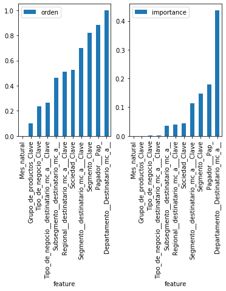

```python
fig, (ax, ax2) = plt.subplots(ncols=2, sharey=False)

tot_cem_res.sort_values(by = 'orden').plot.bar(ax = ax, x = 'feature', y = 'orden')
tot_cem_res.sort_values(by = 'orden').plot.bar(ax = ax2, x = 'feature', y = 'importance')
```

#### Caso Cemento - Gini index

Evaluación de resultado **con** feature selection bajo método actual

```python
secon_eval_cem, secon_model = iden_features(cem_train.copy(), sel_feat.feature.values, y_cols_int)
```

```python
model_pred = secon_model.predict(cem_test[sel_feat.feature.values].values)
```

```python
print('Mean Absolute Error (MAE):', metrics.mean_absolute_error(cem_test[y_cols_int].values, model_pred))
print('Mean Squared Error (MSE):', metrics.mean_squared_error(cem_test[y_cols_int].values, model_pred))
print('Root Mean Squared Error (RMSE):', np.sqrt(metrics.mean_squared_error(cem_test[y_cols_int].values, model_pred)))
```

```
Mean Absolute Error (MAE): 23.734126716802947
Mean Squared Error (MSE): 28587.068884814038
Root Mean Squared Error (RMSE): 169.07710928689914
```

#### **Caso Cemento - mlxtend**

```python
mlx_eval_cem, mlx_model = iden_features(cem_train.copy(), x_cols_int, y_cols_int)

sfs_cem = sfs(mlx_model,
           k_features='best',
           forward=True,
           floating=False,
           verbose=0,
           scoring='r2',
           cv=2)
# Fitting
input_sfs_cem = cem_train.copy()
input_sfs_cem['Mes_natural'] = input_sfs_cem['Mes_natural'].map(dt.datetime.toordinal)

X_train = input_sfs_cem[x_cols_int].values
y_train = input_sfs_cem[y_cols_int].values[:,-1]

sfs_cem = sfs_cem.fit(X_train, y_train)
```

```python
print('\nSequential Forward Selection:')
print(sfs_cem.k_feature_idx_)
print('Features selected:')
print(list(input_sfs_cem.columns[list(sfs_cem.k_feature_idx_)]))
print('CV Score:')
print(sfs_cem.k_score_)
```

```
Sequential Forward Selection:
(3, 5)
Features selected:
['Subsegmento__destinatario_mc_a__', 'Sociedad_Clave']
CV Score:
0.04044520033974136
```

Ahora entrenamos con el subset de características obtenidos con SFS

```python
thir_eval_cem, thir_model = iden_features(cem_train.copy(),
                                            list(input_sfs_cem.columns[list(sfs_cem.k_feature_idx_)]),
                                            y_cols_int)
```

```python
model_pred = thir_model.predict(cem_test[list(input_sfs_cem.columns[list(sfs_cem.k_feature_idx_)])].values)
```

```python
print('Mean Absolute Error (MAE):', metrics.mean_absolute_error(cem_test[y_cols_int].values, model_pred))
print('Mean Squared Error (MSE):', metrics.mean_squared_error(cem_test[y_cols_int].values, model_pred))
print('Root Mean Squared Error (RMSE):', np.sqrt(metrics.mean_squared_error(cem_test[y_cols_int].values, model_pred)))
```

```
Mean Absolute Error (MAE): 53.31427038609633
Mean Squared Error (MSE): 91030.31564543875
Root Mean Squared Error (RMSE): 301.7123060888282
```

### Conclusiones Cemento

Nótese como respecto a las medidas de evaluación de interés el método 1 (Gini) supera al método 2 (Forward selection).

| Medida | Método 1 | Método 2 | Rel. Met2/Met1 |
| --- | --- | --- | --- |
| Mean Absolute Error (MAE) | 23.73412672 | 53.31427039 | 2 |
| Mean Squared Error (MSE) | 28587.06888 | 91030.31565 | 3 |
| Root Mean Squared Error (RMSE) | 169.0771093 | 301.7123061 | 2 |

Donde en el segundo caso las medidas superan hasta el doble del primero, indicando que para el caso cemento el método propuesto supera al del forward selection.

En particular, la medida de error bajo el método uno de $23.7$ resulta muy positiva, dado que es un monto despreciable cuando se habla de toneladas de cemento

### Caso **Concreto**

```python
conc_per = []

for period in list_periods:
    conc_per_df, _ = iden_features(
                        conc_train[conc_train.Mes_natural == period].copy(),
                        x_cols_int, y_cols_int)

    conc_per_df['per'] = pd.to_datetime(period).strftime('%Y-%m')

    conc_per.append(cem_per_df)

# Ponderamos las medidas
res_conc_per = pd.concat(conc_per, ignore_index = False).reset_index(drop = False).rename(columns = {'index' : 'orden'})
tot_conc_res = res_conc_per.groupby('feature').agg({'orden' : 'sum', 'importance' : 'mean'}).reset_index(drop = False)
tot_conc_res['orden'] = (tot_conc_res['orden']-tot_conc_res['orden'].min())/(tot_conc_res['orden'].max()-tot_conc_res['orden'].min())
tot_conc_res['orden'] = 1-tot_conc_res['orden']
```

```python
sel_feat = tot_conc_res.sort_values(by = 'orden', ascending = False)
sel_feat = sel_feat[sel_feat.orden >= 0.6]
sel_feat
```

|  | feature | orden | importance |
| --- | --- | --- | --- |
| 0 | Departamento__Destinatario_mc_a__ | 1.0 | 0.350452 |
| 3 | Pagador___Pap_ | 0.9 | 0.171715 |
| 5 | Segmento_Clave | 0.8 | 0.137973 |
| 6 | Segmento__destinatario_mc_a___Clave | 0.7 | 0.117779 |
| 7 | Sociedad_Clave | 0.6 | 0.101767 |

**Interpretación**

**Explicación gráfica**

La gráfica a continuación muestra, en la primer imagen, la posición agregada en términos de importancia de cada feature, indicando que aquel que se encuentre más a la derecha se posicionó más relevante que el resto; en la segunda imagen se despliega el promedio del coeficiente gini para cada feature

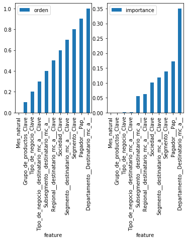

```python
fig, (ax, ax2) = plt.subplots(ncols=2, sharey=False)

tot_conc_res.sort_values(by = 'orden').plot.bar(ax = ax, x = 'feature', y = 'orden')
tot_conc_res.sort_values(by = 'orden').plot.bar(ax = ax2, x = 'feature', y = 'importance')
```

#### Caso Concreto - Gini index

Evaluación de resultado **con** feature selection bajo método actual

```python
secon_eval_con, secon_model = iden_features(conc_train.copy(), sel_feat.feature.values, y_cols_int)
```

```python
model_pred = secon_model.predict(conc_test[sel_feat.feature.values].values)
```

```python
print('Mean Absolute Error (MAE):', metrics.mean_absolute_error(conc_test[y_cols_int].values, model_pred))
print('Mean Squared Error (MSE):', metrics.mean_squared_error(conc_test[y_cols_int].values, model_pred))
print('Root Mean Squared Error (RMSE):', np.sqrt(metrics.mean_squared_error(conc_test[y_cols_int].values, model_pred)))
```

```
Mean Absolute Error (MAE): 175.2495976402315
Mean Squared Error (MSE): 192845.092542935
Root Mean Squared Error (RMSE): 439.141312726251
```

#### **Caso Concreto - mlxtend**

```python
mlx_eval_conc, mlx_model = iden_features(conc_train.copy(), x_cols_int, y_cols_int)

sfs_conc = sfs(mlx_model,
           k_features='best',
           forward=True,
           floating=False,
           verbose=0,
           scoring='r2',
           cv=2)
# Fitting
input_sfs_conc = conc_train.copy()
input_sfs_conc['Mes_natural'] = input_sfs_conc['Mes_natural'].map(dt.datetime.toordinal)

X_train = input_sfs_conc[x_cols_int].values
y_train = input_sfs_conc[y_cols_int].values[:,-1]

sfs_conc = sfs_conc.fit(X_train, y_train)
```

```python
print('\nSequential Forward Selection:')
print(sfs_conc.k_feature_idx_)
print('Features selected:')
print(list(input_sfs_conc.columns[list(sfs_conc.k_feature_idx_)]))
print('CV Score:')
print(sfs_conc.k_score_)
```

```
Sequential Forward Selection:
(5, 7)
Features selected:
['Sociedad_Clave', 'Regional__destinatario_mc_a___Clave']
CV Score:
0.08301866846797906
```

Ahora entrenamos con el subset de características obtenidos con SFS

```python
thir_eval_conc, thir_model = iden_features(conc_train.copy(),
                                            list(input_sfs_conc.columns[list(sfs_conc.k_feature_idx_)]),
                                            y_cols_int)
```

```python
model_pred = thir_model.predict(conc_test[list(input_sfs_conc.columns[list(sfs_conc.k_feature_idx_)])].values)
```

```python
print('Mean Absolute Error (MAE):', metrics.mean_absolute_error(conc_test[y_cols_int].values, model_pred))
print('Mean Squared Error (MSE):', metrics.mean_squared_error(conc_test[y_cols_int].values, model_pred))
print('Root Mean Squared Error (RMSE):', np.sqrt(metrics.mean_squared_error(conc_test[y_cols_int].values, model_pred)))
```

```
Mean Absolute Error (MAE): 334.6439650918108
Mean Squared Error (MSE): 467430.9145302548
Root Mean Squared Error (RMSE): 683.6891943933697
```

### Conclusiones Concreto

El mismo resultado se obtiene para el caso concreto como en el del cemento, donde por medio del método 1 se obtienen medidas de error menores que para el caso 2

| Medida | Método 1 | Método 2 | Rel. Met2/Met1 |
| --- | --- | --- | --- |
| Mean Absolute Error (MAE) | 175.2495976 | 334.6439651 | 2 |
| Mean Squared Error (MSE) | 192845.0925 | 467430.9145 | 2 |
| Root Mean Squared Error (RMSE) | 439.1413127 | 683.6891944 | 2 |

Es importante mencionar que el negocio de concreto maneja volumenes monstruosos, por lo que una medida $MAE$ de $175$ toneladas es una medida de error aceptable